# Aula 2

Paulo C. Jr

2024-04-12

## Equações matemáticas

- Um exemplo de equação matemática $y=ax+b$.
- Exemplo de somatório $\sum_{i=1}^{n}X_{i}=X_{1}+X_{2}+\dots+X_{n}$.
- Usando o `dots` dentro de matrizes:

$$\begin{matrix}
a_{11} & a_{12} & \dots & a_{1n}\\
a_{21} & a_{22} & \dots & a_{2n}\\
\vdots & \vdots & \ddots & \vdots\\
a_{n1} & a_{n2} & \dots & a_{nn}\\
\end{matrix}$$

- Um exemplo usando equações:
- Usando só os cifrões:

```
$$y_{i}=\beta_{0}+\beta_{1}X_{i}+\epsilon_{i}.$$
```

$$y_{i}=\beta_{0}+\beta_{1}X_{i}+\epsilon_{i}.$$

- Usando o ambiente `equation`

```
\begin{equation}
y_{i}=\beta_{0}+\beta_{1}X_{i}+\epsilon_{i}
\end{equation}
```

- Exemplo de função de log-verossimilhança:

$$\ell(\theta| x)=\sum\limits_{i=1}^{n}
\log[f(x_{i}\mid \theta)]$$

## Introdução ao `R`

### Atribuições

Podemos atribuir um valor a um objeto `x`. A forma de atribuir valores em `R`, se dá usando `<-` ou `=`. Exemplo,

Usando a atribuição `<-`, temos

```r
x <- 1
x
```

```
[1] 1
```

No outro caso,

```r
x = 1
x
```

```
[1] 1
```

### Variáveis

As variáveis são os nomes dados aos objetos, como por exemlo, `x`, `y`, `numero_respostas`, etc.

```r
id_faest <- c(35,20,20,23,19,19,20,20,21,20)
id_faest
```

```
 [1] 35 20 20 23 19 19 20 20 21 20
```

em que `c` representa uma concatenação de objetos. Logo, forma um vetor de elementos.

### Caracteres:

Os textos dentro do `R` são considerados usando aspas `" "` ou `' '`.

Por exemplo,

```r
genero <- c("Masculino","Feminino","Feminino",  "Masculino", "Masculino","Feminino","Feminino","Feminino",  "Masculino", "Masculino")
genero
```

```
 [1] "Masculino" "Feminino"  "Feminino"  "Masculino" "Masculino" "Feminino"
 [7] "Feminino"  "Feminino"  "Masculino" "Masculino"
```

Para verificar a classe das variáveis declaradas usamos a função `str`:

```r
str(id_faest)
```

```
 num [1:10] 35 20 20 23 19 19 20 20 21 20
```

```r
str(genero)
```

```
 chr [1:10] "Masculino" "Feminino" "Feminino" "Masculino" "Masculino" ...
```

### Vetores

Vetor é uma sequência de valores numérico ou de caracteres.

- Exemplo 1:

```r
y <- 0:10
y
```

```
 [1]  0  1  2  3  4  5  6  7  8  9 10
```

- Exemplo 2 (função `seq`):

```r
y <- seq(0,10)
y
```

```
 [1]  0  1  2  3  4  5  6  7  8  9 10
```

```r
y <- seq(0,10, by=2)
y
```

```
[1]  0  2  4  6  8 10
```

```r
y <- seq(0,10, length.out=20)
y
```

```
 [1]  0.0000000  0.5263158  1.0526316  1.5789474  2.1052632  2.6315789
 [7]  3.1578947  3.6842105  4.2105263  4.7368421  5.2631579  5.7894737
[13]  6.3157895  6.8421053  7.3684211  7.8947368  8.4210526  8.9473684
[19]  9.4736842 10.0000000
```

- Exemplo 3 (função `rep`):

```r
y <- seq(0,10, by=2)
z <- rep(y,2)
z
```

```
 [1]  0  2  4  6  8 10  0  2  4  6  8 10
```

## Matrizes:

Podemos criar matrizes do seguinte formato:

$$\begin{matrix}
a_{11} & a_{12} & \dots & a_{1n}\\
a_{21} & a_{22} & \dots & a_{2n}\\
\vdots & \vdots & \ddots & \vdots\\
a_{n1} & a_{n2} & \dots & a_{nn}\\
\end{matrix}$$

- Exemplo:

```r
A <- matrix(data=c(1,2,2,1))
A
```

```
     [,1]
[1,]    1
[2,]    2
[3,]    2
[4,]    1
```

```r
A <- matrix(data=c(1,2,2,1), nrow = 2, ncol = 2)
A
```

```
     [,1] [,2]
[1,]    1    2
[2,]    2    1
```

Exemplos de operações com matrizes:

```r
B <- matrix(data=c(2,1,1,2), nrow = 2, ncol = 2)
A # Matriz A
```

```
     [,1] [,2]
[1,]    1    2
[2,]    2    1
```

```r
B # Matriz B
```

```
     [,1] [,2]
[1,]    2    1
[2,]    1    2
```

```r
A+B # Soma de  A e B
```

```
     [,1] [,2]
[1,]    3    3
[2,]    3    3
```

```r
A*B # Produto elemento-elemento de  A e B
```

```
     [,1] [,2]
[1,]    2    2
[2,]    2    2
```

```r
A%*%B # Produto matricial de  A e B
```

```
     [,1] [,2]
[1,]    4    5
[2,]    5    4
```

```r
A/B # Razão elemento-elemento de  A e B
```

```
     [,1] [,2]
[1,]  0.5  2.0
[2,]  2.0  0.5
```

```r
A%*%solve(B) # Razão de  A e B
```

```
     [,1] [,2]
[1,]    0    1
[2,]    1    0
```

### Arrays

Os arrays é um conjunto multidimensional de matrizes.

- Exemplo:

```r
Y <- array(data = 1:10, dim = c(2, 2, 3) )
Y
```

```
, , 1

     [,1] [,2]
[1,]    1    3
[2,]    2    4

, , 2

     [,1] [,2]
[1,]    5    7
[2,]    6    8

, , 3

     [,1] [,2]
[1,]    9    1
[2,]   10    2
```

### Listas:

Uma lista é um conjunto multidimensional qualquer tipo de objeto do `R`.

```r
W <- list( y=seq(1,20, by=2), genero = c("Masculino","Feminino","Feminino",  "Masculino", "Masculino", "Feminino"), A, Y)
W
```

```
$y
 [1]  1  3  5  7  9 11 13 15 17 19

$genero
[1] "Masculino" "Feminino"  "Feminino"  "Masculino" "Masculino" "Feminino"

[[3]]
     [,1] [,2]
[1,]    1    2
[2,]    2    1

[[4]]
, , 1

     [,1] [,2]
[1,]    1    3
[2,]    2    4

, , 2

     [,1] [,2]
[1,]    5    7
[2,]    6    8

, , 3

     [,1] [,2]
[1,]    9    1
[2,]   10    2
```

### Dataframes:

Mais utilizado para bancos de dados:

```r
alt.faest <- c(1.63, 1.83, 1.75, 1.85, 1.60, 1.61, 1.70, 1.70, 1.75, 1.51)

dados <- data.frame(id_faest, genero, alt.faest)
dados
```

| id_faest | genero | alt.faest |
| --- | --- | --- |
| 35 | Masculino | 1.63 |
| 20 | Feminino | 1.83 |
| 20 | Feminino | 1.75 |
| 23 | Masculino | 1.85 |
| 19 | Masculino | 1.60 |
| 19 | Feminino | 1.61 |
| 20 | Feminino | 1.70 |
| 20 | Feminino | 1.70 |
| 21 | Masculino | 1.75 |
| 20 | Masculino | 1.51 |

```r
dados$genero
```

```
 [1] "Masculino" "Feminino"  "Feminino"  "Masculino" "Masculino" "Feminino"
 [7] "Feminino"  "Feminino"  "Masculino" "Masculino"
```

## Indexação

- Vetor:

A indexação para vetores é feita da segunite forma `x[i]`, que significa que temos o valor de `x` na posição `i`. Por exemplo:

```r
#id_faest <- c(....)

## O primeiro valor do vetor idade
i <- 1
id_faest[i]
```

```
[1] 35
```

```r
# Qual a posição do menor valor?
j <- which.min(id_faest)

# Qual a posição do maior valor?
k <- which.max(id_faest)
```

Queremos saber quais são o menor e o maior valor:

```r
a <- c(j, k) # vetor com a posição do min e do máximo
a
```

```
[1] 5 1
```

```r
id_faest[a]
```

```
[1] 19 35
```

- Matrizes:

A indexação para matrizes é feita da seguinte forma `A[i,j]`, que significa que temos o valor de `A` na linha `i` e coluna `j`. Por exemplo:

```r
A
```

```
     [,1] [,2]
[1,]    1    2
[2,]    2    1
```

```r
#Elemento na linha 1 e coluna 2:
i <- 1
j <- 2
A[i,j]
```

```
[1] 2
```

- Arrays:

A indexação para *arrays* é feita da seguinte forma `Y[i,j,k]`, que significa que temos o valor de `Y` na linha `i`, coluna `j` e dimensão `k`. Por exemplo:

```r
Y
```

```
, , 1

     [,1] [,2]
[1,]    1    3
[2,]    2    4

, , 2

     [,1] [,2]
[1,]    5    7
[2,]    6    8

, , 3

     [,1] [,2]
[1,]    9    1
[2,]   10    2
```

```r
#Elemento na linha 1 e coluna 2, na dimensão 2:
i <- 1
j <- 2
k <- 2
Y[i, j, k]
```

```
[1] 7
```

- Listas:

A indexação para listas é feita da seguinte forma `V[[i]]`, que significa que temos a dimensão `i` da lista. Por exemplo:

```r
W
```

```
$y
 [1]  1  3  5  7  9 11 13 15 17 19

$genero
[1] "Masculino" "Feminino"  "Feminino"  "Masculino" "Masculino" "Feminino"

[[3]]
     [,1] [,2]
[1,]    1    2
[2,]    2    1

[[4]]
, , 1

     [,1] [,2]
[1,]    1    3
[2,]    2    4

, , 2

     [,1] [,2]
[1,]    5    7
[2,]    6    8

, , 3

     [,1] [,2]
[1,]    9    1
[2,]   10    2
```

```r
# Consultando dentro da lista
# Vetor:
W[[1]][c(1,2,3)]
```

```
[1] 1 3 5
```

```r
# Vetor caracteres:
W[[2]][1]
```

```
[1] "Masculino"
```

```r
# Matriz:
W[[3]][1,]
```

```
[1] 1 2
```

```r
# Array:
W[[4]][1,,2]
```

```
[1] 5 7
```

## Programação Básica

Veremos alguma estruturas de contole.

### Condição:

- `IF(){}ELSE(){}`:

Usaremos o exemplo de uma equação do 2 grau, em que

$$a_1 x^2 + a_2 x + a_3 =0.$$

Definindo os coeficientes, temos:

```r
a1 <- 1
a2 <- 2
a3 <- 1

delta <- a2^2 - 4*a1*a3

if(delta > 0){
  x1 <- (-a2+sqrt(delta))/2*a1
  x2 <- (-a2-sqrt(delta))/2*a1
  cat("As raízes reais são ", x1, "e", x2, ".", sep=" ")
}else{
    if(delta == 0){
      x1 <- -a2/2*a1
      cat("A raíz real é ", x1, ".", sep=" ")
    }else{
      cat("Não há raíz real.", sep=" ")
    }
}
```

```
A raíz real é  -1 .
```

- `ifelse`: mudanção de elementos dentro de um objeto baseado em uma condição.

Para o exemplo com a variável gênero:

```r
genero
```

```
 [1] "Masculino" "Feminino"  "Feminino"  "Masculino" "Masculino" "Feminino"
 [7] "Feminino"  "Feminino"  "Masculino" "Masculino"
```

```r
genero_cod <- ifelse( genero=="Masculino", 1, 0)
genero_cod
```

```
 [1] 1 0 0 1 1 0 0 0 1 1
```

Para o exemplo com a variável idade:

```r
id_faest
```

```
 [1] 35 20 20 23 19 19 20 20 21 20
```

```r
id_cod <- ifelse( id_faest<20, "Novinho(a)", "Velinho(a)")
id_cod
```

```
 [1] "Velinho(a)" "Velinho(a)" "Velinho(a)" "Velinho(a)" "Novinho(a)"
 [6] "Novinho(a)" "Velinho(a)" "Velinho(a)" "Velinho(a)" "Velinho(a)"
```

## Loops:

- Exemplo da soma:

```r
sum(id_faest)
```

```
[1] 217
```

Somando na mão, que não devemos fazer!

```
id_faest[1]+id_faest[2]+id_faest[3]+...
```

- O `for`

É um tipo de `loop` em que:

```
for(var in vet){

}
```

No caso da soma, temos

```r
id_faest
```

```
 [1] 35 20 20 23 19 19 20 20 21 20
```

```r
soma <- 0

for(i in id_faest){
  soma <- soma + i
}
soma
```

```
[1] 217
```

Usando indaxação:

```r
id_faest
```

```
 [1] 35 20 20 23 19 19 20 20 21 20
```

```r
soma <- 0
n <- length(id_faest)
for(i in 1:n){
  soma <- soma + id_faest[i]
}
soma
```

```
[1] 217
```

- Loop `while`:

É um tipo de `loop` em que:

```
while(cond){

}
```

Usando o exemplo da soma. Precisamos somar todos os `n` elementos. Logo,

```r
n <- length(id_faest)
soma <- 0
i <- 1 # Primeiro individuo
while(i<=n){
  soma <- soma + id_faest[i]
  i <- i+1
}
soma
```

```
[1] 217
```

## Funções

Temos como exemplo a função `sum()` que calcula a soma dos elementos de um vetor. Podemos criar nossas próprias funções usando `function(arg1, arg2, ...){ expressões da função }`.

- Exemplo da soma:

```r
soma <- function(x=x, remove.na=FALSE){
  if(remove.na== TRUE ){
    x <- x[ is.na(x) == FALSE]
  }

  n <- length(x)
  somax <- 0
  for(i in 1:n){
    somax <- somax+x[i]
  }
  return(somax) # retorna o valor da soma
}

## Somando a idade sum():

sum(id_faest)
```

```
[1] 217
```

```r
## Somando a idade soma():

soma(id_faest)
```

```
[1] 217
```

- Exemplo com `NA`:

No `R` o `NA` representa o *not avaliable* (não disponível). Assim, seja o segunite vetor:

```r
teste <- c(id_faest, NA)
teste
```

```
 [1] 35 20 20 23 19 19 20 20 21 20 NA
```

```r
is.na(teste)
```

```
 [1] FALSE FALSE FALSE FALSE FALSE FALSE FALSE FALSE FALSE FALSE  TRUE
```

```r
teste[is.na(teste)==FALSE]
```

```
 [1] 35 20 20 23 19 19 20 20 21 20
```

- Realizando a soma sem remover:

```r
soma(teste)
```

```
[1] NA
```

- Realizando a soma removendo:

```r
soma(x=teste, remove.na = TRUE)
```

```
[1] 217
```

- Exemplo com a função variância:

Sabemos que a variância é definida por

$$S^{2}=\dfrac{1}{n-1}\sum\limits_{i=1}^{n}(x_{i}-\overline{x})^2.$$

No `R`, temos inicialmente que criar a função de média. Logo,

```r
media <- function(x=x, remove.na=FALSE){
  if(remove.na== TRUE ){
    x <- x[ is.na(x) == FALSE]
  }

  n <- length(x)
  somax <- 0
  for(i in 1:n){
    somax <- somax+x[i]
  }
  return(somax/n) # retorna o valor da media
}
```

Assim a função da variância é dada por:

```r
variancia <- function(x=x, remove.na=FALSE){
  if(remove.na== TRUE ){
    x <- x[ is.na(x) == FALSE]
  }
  n     <- length(x)
  difx  <- (x-media(x=x))^2
  varx  <- soma(difx)/(n-1)

  return(varx)

}
```

Calculando a variância para o vetor `teste`, temos

```r
variancia(x=teste, remove.na = TRUE)
```

```
[1] 23.12222
```

```r
var(teste, na.rm = TRUE)
```

```
[1] 23.12222
```

## Leitura de bases de dados:

- Aqruivo de texto `.txt`:

A função para este caso é a `read.table()`. Para os dados `banco_aula.txt`, temos:

```r
dados.txt <- read.table(file="banco_aula.txt", header = TRUE, sep="",
                        dec =",")
dados.txt
```

| Id | Idade | Sexo | Altura |
| --- | --- | --- | --- |
| 1 | 27 | Masc | 1.65 |
| 2 | 51 | Fem | 1.72 |
| 3 | 18 | Fem | 1.78 |
| 4 | 32 | Masc | 1.80 |
| 5 | 10 | Masc | 1.40 |
| 6 | 20 | Fem | 1.55 |
| 7 | 24 | Fem | 1.84 |
| 8 | 22 | Fem | 1.69 |
| 9 | 51 | Masc | 1.78 |
| 10 | 32 | Fem | 1.75 |

- Aqruivo de texto `.csv`:

A função para este caso é a `read.csv()`. Para os dados `banco_aula.csv`, temos:

```r
dados.csv <- read.csv(file="banco_aula.csv", header = TRUE, sep=";",
                        dec =",")
dados.csv
```

| Id | Idade | Sexo | Altura |
| --- | --- | --- | --- |
| 1 | 27 | Masc | 1.65 |
| 2 | 51 | Fem | 1.72 |
| 3 | 18 | Fem | 1.78 |
| 4 | 32 | Masc | 1.80 |
| 5 | 10 | Masc | 1.40 |
| 6 | 20 | Fem | 1.55 |
| 7 | 24 | Fem | 1.84 |
| 8 | 22 | Fem | 1.69 |
| 9 | 51 | Masc | 1.78 |
| 10 | 32 | Fem | 1.75 |

- Arquivo do excel `.xlsx`

Para a leitura dos dados vamos precisar do pacote `readxl`. No console, use `install.packages("readxl")` para instalar, caso não tenha feito isso.

```r
require(readxl)
dados.xlsx <- read_xlsx(path = "banco_aula.xlsx", sheet = 1)
dados.xlsx
```

| Id | Idade | Sexo | Altura |
| --- | --- | --- | --- |
| 1 | 27 | Masc | 1.65 |
| 2 | 51 | Fem | 1.72 |
| 3 | 18 | Fem | 1.78 |
| 4 | 32 | Masc | 1.80 |
| 5 | 10 | Masc | 1.40 |
| 6 | 20 | Fem | 1.55 |
| 7 | 24 | Fem | 1.84 |
| 8 | 22 | Fem | 1.69 |
| 9 | 51 | Masc | 1.78 |
| 10 | 32 | Fem | 1.75 |

## Gráficos para variáveis quantitativas:

A funação mais simples para qualquer gráfico é `plot()`.

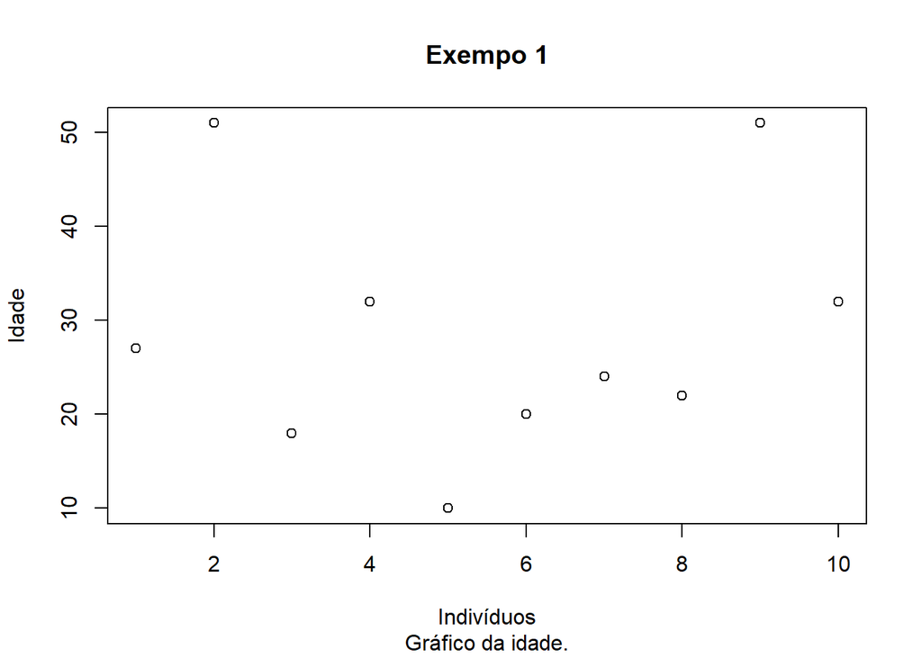

```r
#par(mfrow=c(1,2))
plot(dados.xlsx$Idade, xlab="Indivíduos",
     ylab="Idade", main="Exempo 1", sub="Gráfico da idade.")
```

### Gráfico de dispersão:

Vamos avaliar a relação entre duas variáveis quantitativas.

No caso da Idade e Altura, a medida de correlação de Pearson é 0.5128216. Logo, como o valor da correlação é positivo, tem-se o indicativo de que a correlação é positiva linear crescente.

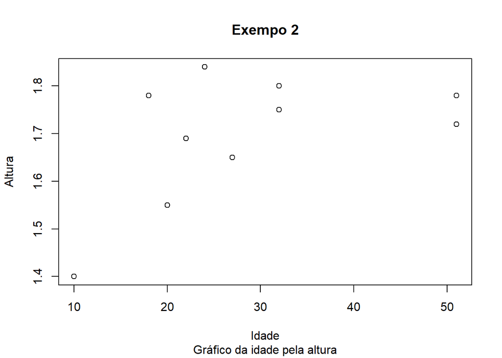

```r
plot(dados.xlsx$Idade, dados.xlsx$Altura, xlab="Idade",
     ylab="Altura", main="Exempo 2", sub="Gráfico da idade pela altura")
```

### Histograma:

Este gráfico serve para avaliar distribuição dos dados.

- Exemplo usando a variável Altura:

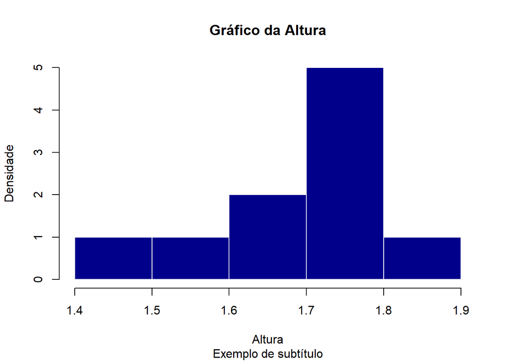

```r
hist(x=dados.xlsx$Altura,ylab="Densidade", xlab="Altura", main="Gráfico da Altura", sub="Exemplo de subtítulo", col = "darkblue", border = "white", freq = FALSE)
```

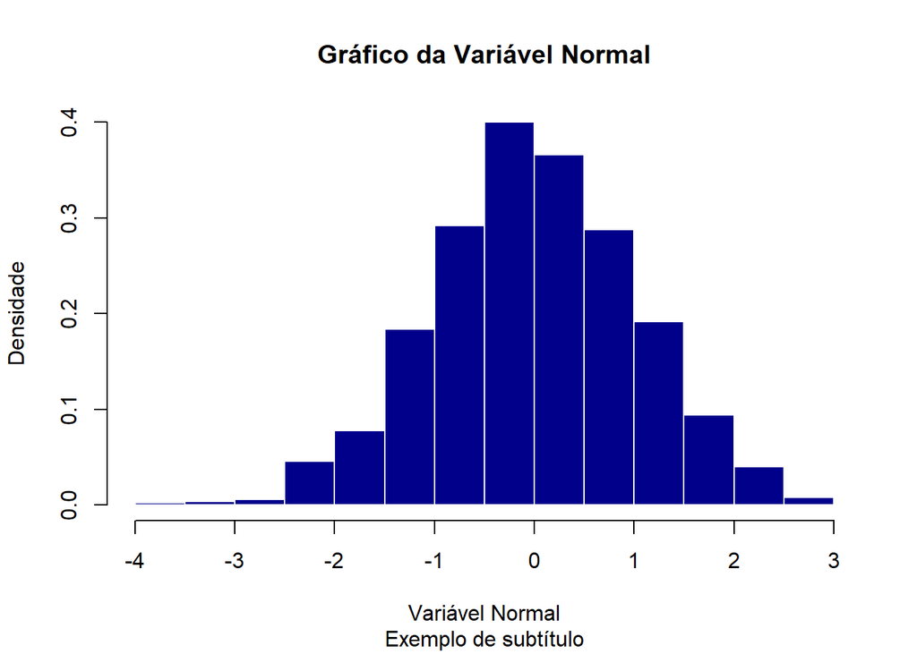

```r
x <- rnorm(1000)
hist(x,ylab="Densidade", xlab="Variável Normal", main="Gráfico da Variável Normal", sub="Exemplo de subtítulo", col = "darkblue", border = "white", freq = FALSE)
```

### Gráfico de caixa (Boxplot):

Serve para avaliar a distribuição de um conjunto d dados, assim como fornecer informações como medidas de resumo e outras características.

- Na forma horizontal:

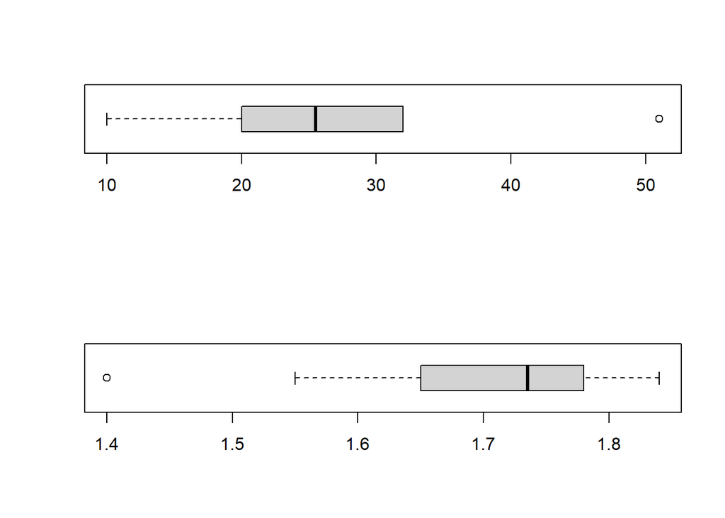

```r
par(mfrow=c(2,1))
boxplot(dados.xlsx$Idade, horizontal = TRUE)
boxplot(dados.xlsx$Altura, horizontal = TRUE)
```

- Na forma vertical:

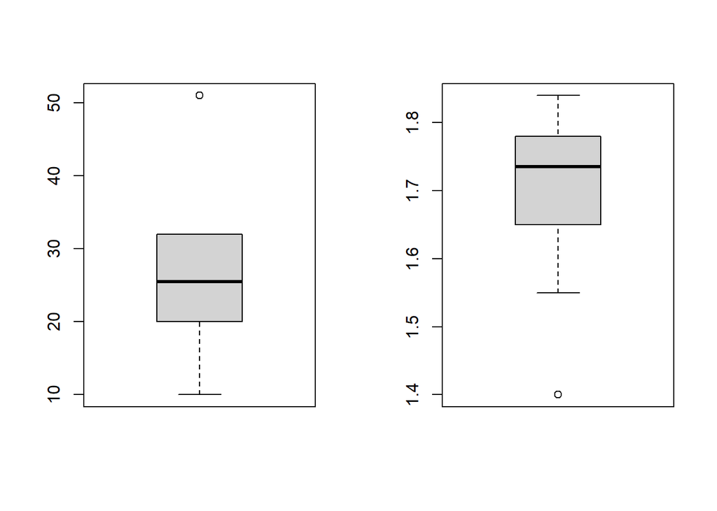

```r
par(mfrow=c(1,2))
boxplot(dados.xlsx$Idade, horizontal = FALSE)
boxplot(dados.xlsx$Altura, horizontal = FALSE)
```

- Gráfico de caixa por grupo:

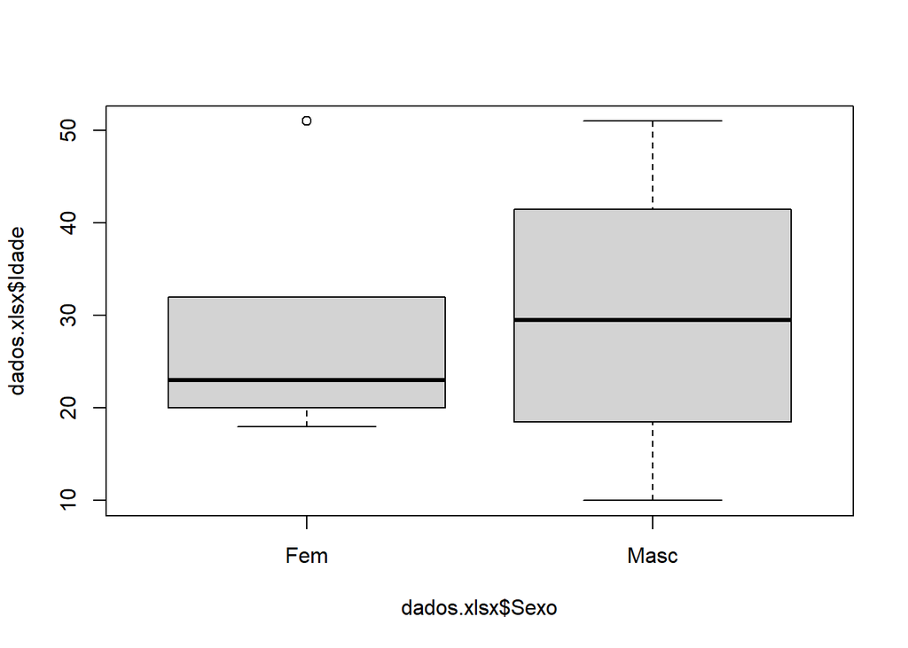

```r
boxplot(dados.xlsx$Idade~dados.xlsx$Sexo)
```

## Gráficos para variáveis qualitativas:

Para realizar uma tabela de frequências, você precisa usar o comando `table()`.

- Exemplo variável Sexo:

A distribuição de frequências:

```r
tabelaSexo <- table(dados.xlsx$Sexo)
tabelaSexo
```

```
 Fem Masc
   6    4
```

A proporção de cada grupo:

```r
ProptabelaSexo <- prop.table(table(dados.xlsx$Sexo))
ProptabelaSexo*100
```

```
 Fem Masc
  60   40
```

O gráfico de barras:

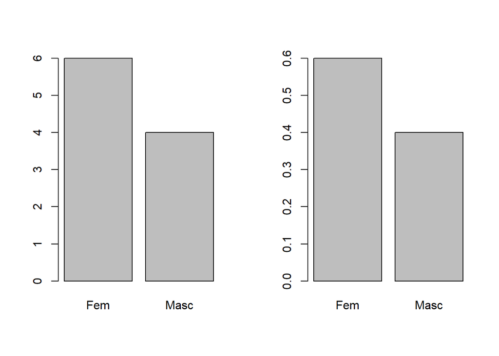

```r
par(mfrow=c(1,2))
barplot(tabelaSexo)
barplot(ProptabelaSexo)
```